# R Notebook

Result: - The Ljung-Box test, conducted on the stock return time series, yielded an X-squared value of 0.52502 with 1 degree of freedom and a p-value of 0.4687. Given the high p-value (greater than the typical significance level of 0.05), there is insufficient evidence to reject the null hypothesis, which suggests that the stock return time series does not exhibit significant autocorrelation at lag 1.

Implication: The lack of significant autocorrelation in the stationary stock return time series implies that past returns are not a reliable predictor of future returns at the first lag. This characteristic is consistent with the Efficient Market Hypothesis (EMH), which posits that asset prices fully reflect all available information, making it difficult to achieve consistently higher returns than the market average. For traders and analysts, this result suggests that simple predictive models based on past returns may not be effective for forecasting future returns of this stock at the first lag. However, it’s important to consider autocorrelation at other lags or incorporate additional variables or more sophisticated models for a comprehensive analysis.

```r
# Auto ARIMA
arma_pq_stk_ret = auto.arima(stock_ret); arma_pq_stk_ret
```

```
Series: stock_ret
ARIMA(0,0,0) with zero mean

sigma^2 = 0.0004515:  log likelihood = 3600.16
AIC=-7198.33   AICc=-7198.32   BIC=-7193.03
```

```r
arma_pq_stk = auto.arima(stock_price); arma_pq_stk
```

```
Series: stock_price
ARIMA(0,1,0)

sigma^2 = 49.67:  log likelihood = -4990.03
AIC=9982.06   AICc=9982.06   BIC=9987.36
```

Objective: To identify an optimal autoregressive integrated moving average (ARIMA) model for the stock return time series.

Analysis: The auto.arima function was utilized to automatically select the best fitting ARIMA model for the stock return time series. This function iteratively explores various combinations of AR (autoregression), I (integration), and MA (moving average) components to find the model that best captures the time series data according to information criteria such as the Akaike Information Criterion (AIC), the corrected AIC (AICc), and the Bayesian Information Criterion (BIC).

Result: - The auto.arima function identified an ARIMA(0,0,0) model with zero mean as the best fit for the stock return time series. This model, also known as a white noise model, indicates that there are no AR or MA components required to model the data effectively. The model parameters are as follows: - sigma^2 (variance of the model’s errors) = 0.0004515 - Log likelihood = 3600.16 - AIC = -7198.33 - AICc = -7198.32 - BIC = -7193.03

Implication: The selection of an ARIMA(0,0,0) model with zero mean suggests that the stock return time series behaves as a random walk or white noise process, where future values cannot be predictably determined from past values. This outcome reinforces the notion of market efficiency within the context of the analyzed data, indicating that the stock returns do not exhibit autocorrelations or patterns that could be exploited for predictive purposes. For financial analysts and investors, this model implies that traditional time series forecasting techniques may not be effective in predicting future returns of this stock, highlighting the importance of considering other factors or employing different strategies for investment decision-making. Arima 2 Objective: To determine the most suitable ARIMA model for the stock price time series.

Analysis: The auto.arima function, a tool designed to automatically identify the best ARIMA model, was applied to the stock price time series. This function assesses various combinations of the AR (autoregression), I (integration), and MA (moving average) parameters to select a model that optimally fits the data based on specific criteria, such as the Akaike Information Criterion (AIC), the corrected Akaike Information Criterion (AICc), and the Bayesian Information Criterion (BIC).

Result: - The optimal ARIMA model identified for the stock price time series is an ARIMA(0,1,0). This model does not include any autoregressive (AR) or moving average (MA) components but indicates that differencing the data once (I=1) renders it stationary. The model parameters are detailed as follows: - sigma^2 (the variance of the model’s errors) = 49.67 - Log likelihood = -4990.03 - AIC = 9982.06 - AICc = 9982.06 - BIC = 9987.36

Implication: The selection of an ARIMA(0,1,0) model suggests that the stock price series is a random walk with no predictable pattern in its fluctuations when differenced once. This characteristic is common in financial time series, supporting the hypothesis that stock prices follow a random walk and thus, their future prices are not directly predictable based on past values alone. For market participants, this finding underscores the challenge of forecasting future stock prices using historical price data alone and highlights the importance of incorporating a broader range of market analysis, financial indicators, and possibly, external economic factors for effective investment strategies.

```r
# Ljung-Box Test for Autocorrelation - Model Residuals
# ****************************************************
lb_test_arma_pq_stk_ret = Box.test(arma_pq_stk_ret$residuals); lb_test_arma_pq_stk_ret
```

```
    Box-Pierce test

data:  arma_pq_stk_ret$residuals
X-squared = 0.52502, df = 1, p-value = 0.4687
```

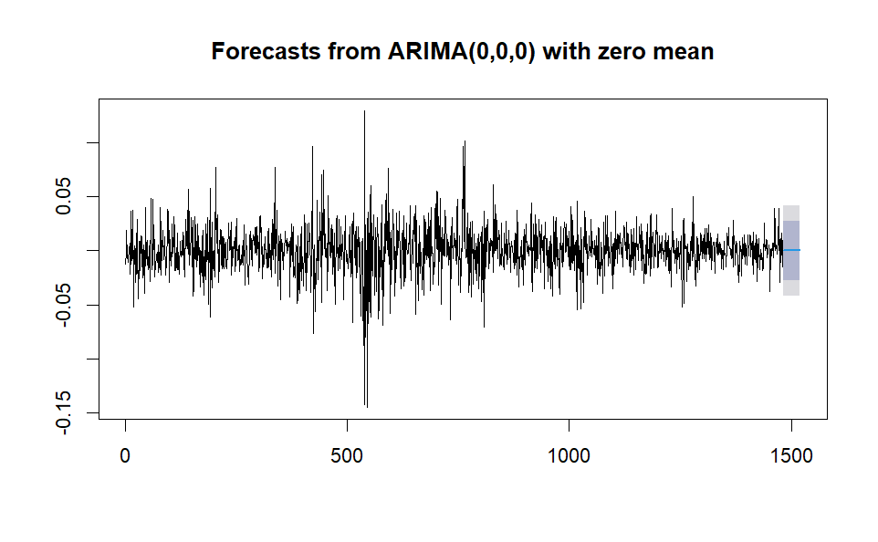

```r
# Forecasting with ARIMA Models
# ************************************
# jj_ds_f11 = predict(arma11, n.ahead = 40)
# plot(jj_ds_f11)
# lines(jj_ds_f11$pred, col = 'blue')
# lines(jj_ds_f11$pred + 2 * jj_ds_f11$se, col = 'red')
# lines(jj_ds_f11$pred - 2 * jj_ds_f11$se, col = 'red')

stock_ret_fpq = forecast(arma_pq_stk_ret, h = 40)
plot(stock_ret_fpq)
```

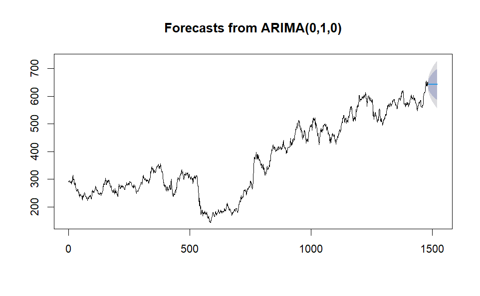

```r
stock_fpq = forecast(arma_pq_stk, h = 40)
plot(stock_fpq)
```

Objective: To examine the presence of autocorrelation in the residuals of the fitted ARIMA model for the stock return time series.

Analysis: The Ljung-Box test, specifically the Box-Pierce version in this case, was conducted on the residuals of the ARIMA model fitted to the stock return time series. This statistical test is crucial for model diagnostics, aiming to detect any remaining autocorrelation in the residuals that could indicate a lack of fit or the potential for further model improvement. Autocorrelation in the residuals suggests that some pattern in the data has not been captured by the model, which could potentially be exploited for better predictions.

Result: - The Ljung-Box test applied to the residuals of the ARIMA model yielded an X-squared value of 0.52502 with 1 degree of freedom and a p-value of 0.4687. Given the relatively high p-value (greater than the typical significance level of 0.05), there is insufficient evidence to reject the null hypothesis, indicating that the residuals do not exhibit significant autocorrelation at the first lag.

Implication: The lack of significant autocorrelation in the residuals of the fitted ARIMA model for the stock return time series suggests that the model has adequately captured the underlying process generating the data. This result implies that the residuals are essentially random, as desired in a well-fitted time series model, indicating no obvious patterns or trends that the model failed to capture. For analysts and investors, this finding supports the reliability of the selected ARIMA(0,0,0) model with zero mean for forecasting purposes, underlining that the model residuals do not contain autocorrelations that could have been leveraged to improve the model further.

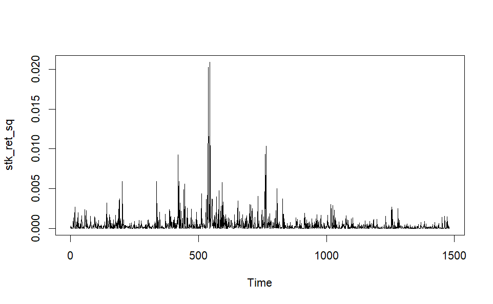

```r
# Test for Volatility Clustering or Heteroskedasticity: Box Test
stk_ret_sq = arma_pq_stk_ret$residuals^2 # Return Variance (Since Mean Returns is approx. 0)
plot(stk_ret_sq)
```

```r
stk_ret_sq_box_test = Box.test(stk_ret_sq, lag = 10) # H0: Return Variance Series is Not Serially Correlated
stk_ret_sq_box_test # Inference : Return Variance Series is Heteroskedastic (Has Volatility Clustering)
```

```
    Box-Pierce test

data:  stk_ret_sq
X-squared = 463.71, df = 10, p-value < 2.2e-16
```

```r
# Test for Volatility Clustering or Heteroskedasticity: ARCH Test
stk_ret_arch_test = ArchTest(arma_pq_stk_ret$residuals, lags = 10) # H0: No ARCH Effects
stk_ret_arch_test # Inference : Return Series is Heteroskedastic (Has Volatility Clustering)
```

```
    ARCH LM-test; Null hypothesis: no ARCH effects

data:  arma_pq_stk_ret$residuals
Chi-squared = 222.71, df = 10, p-value < 2.2e-16
```

Objective: To assess the presence of volatility clustering or heteroskedasticity in the stock return series, which indicates whether variances of the series change over time.

Analysis: Two tests were conducted on the squared residuals of the fitted ARIMA model to the stock return series to detect volatility clustering or heteroskedasticity:

1. **Box Test for Serial Correlation in Return Variance:** Squaring the residuals emphasizes variations in volatility, making it easier to detect patterns of volatility clustering. The Box-Pierce test, a form of the Ljung-Box test, was applied to these squared residuals with a lag of 10 to test for serial correlation.
2. **ARCH (Autoregressive Conditional Heteroskedasticity) Test:** This test specifically looks for ARCH effects, where current period variances are dependent on the variances of previous periods, indicating volatility clustering.

Result: - **Box-Pierce Test:** The test yielded an X-squared value of 463.71 with 10 degrees of freedom and a p-value less than 2.2e-16. This statistically significant result strongly rejects the null hypothesis, indicating that the return variance series is serially correlated, suggesting volatility clustering or heteroskedasticity.

- **ARCH Test:** The ARCH test reported a Chi-squared value of 222.71 with 10 degrees of freedom and a p-value less than 2.2e-16. Similar to the Box-Pierce test, this result significantly rejects the null hypothesis of no ARCH effects, confirming the presence of heteroskedasticity or volatility clustering in the return series.

Implication: The presence of volatility clustering or heteroskedasticity in the stock return series has significant implications for financial modeling and risk management. This phenomenon, where large changes in returns are likely to be followed by large changes (of either sign) and small changes by small changes, challenges the assumption of constant volatility used in many financial models, including the basic ARIMA model for returns. For investors and risk managers, acknowledging volatility clustering is crucial for accurate risk assessment, option pricing, and portfolio management. It suggests the need for models that can adapt to changing variances over time, such as GARCH (Generalized Autoregressive Conditional Heteroskedasticity) models, to better forecast future volatility and optimize investment strategies.

```r
# GARCH Model
garch_model1 = ugarchspec(variance.model = list(model = 'sGARCH', garchOrder = c(1,1)), mean.model = list(armaOrder = c(0,0), include.mean = TRUE))
nse_ret_garch1 = ugarchfit(garch_model1, data = arma_pq_stk_ret$residuals); nse_ret_garch1
```

```
*---------------------------------*
*          GARCH Model Fit        *
*---------------------------------*

Conditional Variance Dynamics
-----------------------------------
GARCH Model : sGARCH(1,1)
Mean Model  : ARFIMA(0,0,0)
Distribution    : norm

Optimal Parameters
------------------------------------
        Estimate  Std. Error  t value Pr(>|t|)
mu      0.000873    0.000461   1.8952 0.058062
omega   0.000009    0.000003   3.3645 0.000767
alpha1  0.077532    0.009470   8.1873 0.000000
beta1   0.903521    0.010507  85.9909 0.000000

Robust Standard Errors:
        Estimate  Std. Error  t value Pr(>|t|)
mu      0.000873    0.000472   1.8508 0.064202
omega   0.000009    0.000005   1.6297 0.103171
alpha1  0.077532    0.011738   6.6053 0.000000
beta1   0.903521    0.020302  44.5037 0.000000

LogLikelihood : 3737.259

Information Criteria
------------------------------------

Akaike       -5.0449
Bayes        -5.0306
Shibata      -5.0450
Hannan-Quinn -5.0396

Weighted Ljung-Box Test on Standardized Residuals
------------------------------------
                        statistic p-value
Lag[1]                     0.1127  0.7371
Lag[2*(p+q)+(p+q)-1][2]    0.3936  0.7458
```

[output cut: 19 more lines]

```
Nyblom stability test
------------------------------------
Joint Statistic:  3.2173
Individual Statistics:
mu     0.0761
omega  1.3816
alpha1 0.4512
beta1  0.4351

Asymptotic Critical Values (10% 5% 1%)
Joint Statistic:         1.07 1.24 1.6
Individual Statistic:    0.35 0.47 0.75

Sign Bias Test
------------------------------------
```

|  | t-value | prob | sig |
| --- | --- | --- | --- |
| Sign Bias | 1.9524880 | 0.05106923 | * |
| Negative Sign Bias | 0.9522839 | 0.34110903 |  |
| Positive Sign Bias | 1.8683213 | 0.06191542 | * |
| Joint Effect | 8.7677435 | 0.03254368 | ** |

```
Adjusted Pearson Goodness-of-Fit Test:
------------------------------------
  group statistic p-value(g-1)
1    20     53.11    4.508e-05
2    30     64.35    1.724e-04
3    40     80.92    9.265e-05
4    50     90.41    2.919e-04


Elapsed time : 0.435204
```

```r
garch_model2 = ugarchspec(variance.model = list(model = 'sGARCH', garchOrder = c(1,1)), mean.model = list(armaOrder = c(4,5), include.mean = FALSE))
nse_ret_garch2 = ugarchfit(garch_model2, data = arma_pq_stk_ret$residuals); nse_ret_garch2
```

```
*---------------------------------*
*          GARCH Model Fit        *
*---------------------------------*

Conditional Variance Dynamics
-----------------------------------
GARCH Model : sGARCH(1,1)
Mean Model  : ARFIMA(4,0,5)
Distribution    : norm

Optimal Parameters
------------------------------------
        Estimate  Std. Error    t value Pr(>|t|)
ar1    -0.186672    0.024781    -7.5328 0.000000
ar2     0.743064    0.017501    42.4579 0.000000
ar3     0.531942    0.020016    26.5760 0.000000
ar4    -0.531350    0.025524   -20.8180 0.000000
ma1     0.197057    0.002183    90.2694 0.000000
ma2    -0.732734    0.004491  -163.1415 0.000000
ma3    -0.531038    0.000302 -1758.0310 0.000000
ma4     0.546048    0.000493  1108.0093 0.000000
ma5     0.007244    0.001291     5.6100 0.000000
omega   0.000008    0.000004     2.2090 0.027174
alpha1  0.075594    0.009405     8.0375 0.000000
beta1   0.907349    0.009740    93.1577 0.000000

Robust Standard Errors:
        Estimate  Std. Error    t value Pr(>|t|)
ar1    -0.186672    0.030107   -6.20037   0.0000
ar2     0.743064    0.016138   46.04536   0.0000
ar3     0.531942    0.022273   23.88300   0.0000
ar4    -0.531350    0.030174  -17.60967   0.0000
ma1     0.197057    0.002246   87.74932   0.0000
ma2    -0.732734    0.004987 -146.91447   0.0000
ma3    -0.531038    0.000797 -666.59940   0.0000
ma4     0.546048    0.000408 1337.11946   0.0000
ma5     0.007244    0.001256    5.76886   0.0000
omega   0.000008    0.000009    0.90417   0.3659
alpha1  0.075594    0.013580    5.56657   0.0000
beta1   0.907349    0.025124   36.11547   0.0000
```

[output cut: 43 more lines]

```
ma1    0.03332
ma2    0.06078
ma3    0.09451
ma4    0.09423
ma5    0.05229
omega  1.04687
alpha1 0.42328
beta1  0.40834

Asymptotic Critical Values (10% 5% 1%)
Joint Statistic:         2.69 2.96 3.51
Individual Statistic:    0.35 0.47 0.75

Sign Bias Test
------------------------------------
```

|  | t-value | prob | sig |
| --- | --- | --- | --- |
| Sign Bias | 0.5545443 | 0.5792905 |  |
| Negative Sign Bias | 1.6052271 | 0.1086579 |  |
| Positive Sign Bias | 0.9717187 | 0.3313498 |  |
| Joint Effect | 5.1569989 | 0.1606553 |  |

```
Adjusted Pearson Goodness-of-Fit Test:
------------------------------------
  group statistic p-value(g-1)
1    20     51.70    7.329e-05
2    30     70.88    2.297e-05
3    40     77.89    2.140e-04
4    50     98.92    3.172e-05


Elapsed time : 2.146304
```

```r
# Test for Volatility Clustering or Heteroskedasticity: ARCH Test
gar_resd = residuals(nse_ret_garch2)^2
stk_ret_arch_test1 = ArchTest(gar_resd, lags = 1) # H0: No ARCH Effects
stk_ret_arch_test1 # Inference : Return Series is Heteroskedastic (Has Volatility Clustering)
```

```
    ARCH LM-test; Null hypothesis: no ARCH effects

data:  gar_resd
Chi-squared = 125.84, df = 1, p-value < 2.2e-16
```

Garch model 1 Objective: To analyze the volatility of stock returns using the GARCH model.

Analysis: The GARCH(1,1) model was fitted on the residuals of the stock returns to understand the volatility dynamics. The model includes a constant mean (ARFIMA(0,0,0)) and assumes a normal distribution for the error terms. The optimal parameters, along with their standard errors, t-values, and p-values, indicate the significance and impact of each component on the model. The diagnostics include various tests for serial correlation, ARCH effects, stability, and goodness-of-fit to assess the model’s adequacy.

Implication: The GARCH(1,1) model effectively captures the volatility dynamics in the stock returns, indicating significant and persistent volatility clustering. However, the presence of residual ARCH effects and the goodness-of-fit tests suggest that exploring more complex GARCH models or alternative distributions for the error terms could potentially improve the model. This analysis is crucial for understanding risk and for making informed investment decisions, as it highlights the importance of considering volatility in the financial markets.

Garch model 2 **Objective:** To analyze the volatility and predict future movements in stock returns using the GARCH model.

**Analysis:** In this segment, a sophisticated GARCH(1,1) model combined with an ARFIMA(4,0,5) mean model was employed to fit the time series of stock return residuals. This approach allows for capturing both the persistence of volatility and the dynamics of the mean return. The distribution assumed for the residuals is normal. The analysis includes checking for the model’s fit, the significance of its parameters, and conducting diagnostic tests for serial correlation, ARCH effects, and the stability of the parameters over time.

**Implication:** The fitted GARCH(1,1) model with an ARFIMA(4,0,5) mean component effectively captures the conditional volatility and mean dynamics of the stock return series, evidenced by significant parameter estimates and generally favorable diagnostic tests. However, the presence of residual ARCH effects suggests that further refinement of the model, such as exploring different distributions for residuals or incorporating additional terms, could improve the model’s performance. This model serves as a valuable tool for forecasting future volatility, which is crucial for risk management and derivative pricing in financial markets.

### Objective: To analyze the volatility and stability of stock returns using the GARCH model.

### Analysis:

In this analysis, a GARCH(1,1) model was fitted to the residuals of stock returns to understand the volatility dynamics. The model includes parameters for the mean (mu), variance (omega), and GARCH coefficients (alpha1 for ARCH and beta1 for GARCH effects). Several statistical tests and metrics were used to evaluate the model fit and the characteristics of the stock return series.

### Implication:

- The analysis confirms the stock returns exhibit volatility clustering, a common characteristic in financial time series, where large changes in returns are likely to be followed by large changes (of either sign), and small changes are likely to be followed by small changes.
- The significant GARCH(1,1) model parameters indicate that past volatility (alpha1) and conditional variance (beta1) are predictive of future volatility, suggesting a level of predictability in the volatility of stock returns.
- The presence of leverage effects and the need for model improvements suggest that investors and risk managers should consider more complex models or additional variables to better capture the dynamics of stock returns.
- The confirmed presence of heteroskedasticity through the ARCH test highlights the importance of using volatility models like GARCH for financial time series analysis, as assumptions of constant volatility may lead to misestimation of risk and suboptimal investment decisions.

```r
garch_modelf = ugarchspec(variance.model = list(model = 'sGARCH', garchOrder = c(1,1)), mean.model = list(armaOrder = c(4,5), include.mean = FALSE))
stk_ret_garch = ugarchfit(garch_modelf, data = stock_ret); stk_ret_garch
```

```
*---------------------------------*
*          GARCH Model Fit        *
*---------------------------------*

Conditional Variance Dynamics
-----------------------------------
GARCH Model : sGARCH(1,1)
Mean Model  : ARFIMA(4,0,5)
Distribution    : norm

Optimal Parameters
------------------------------------
        Estimate  Std. Error    t value Pr(>|t|)
ar1    -0.186672    0.024781    -7.5328 0.000000
ar2     0.743064    0.017501    42.4579 0.000000
ar3     0.531942    0.020016    26.5760 0.000000
ar4    -0.531350    0.025524   -20.8180 0.000000
ma1     0.197057    0.002183    90.2694 0.000000
ma2    -0.732734    0.004491  -163.1415 0.000000
ma3    -0.531038    0.000302 -1758.0310 0.000000
ma4     0.546048    0.000493  1108.0093 0.000000
ma5     0.007244    0.001291     5.6100 0.000000
omega   0.000008    0.000004     2.2090 0.027174
alpha1  0.075594    0.009405     8.0375 0.000000
beta1   0.907349    0.009740    93.1577 0.000000

Robust Standard Errors:
        Estimate  Std. Error    t value Pr(>|t|)
ar1    -0.186672    0.030107   -6.20037   0.0000
ar2     0.743064    0.016138   46.04536   0.0000
ar3     0.531942    0.022273   23.88300   0.0000
ar4    -0.531350    0.030174  -17.60967   0.0000
ma1     0.197057    0.002246   87.74932   0.0000
ma2    -0.732734    0.004987 -146.91447   0.0000
ma3    -0.531038    0.000797 -666.59940   0.0000
ma4     0.546048    0.000408 1337.11946   0.0000
ma5     0.007244    0.001256    5.76886   0.0000
omega   0.000008    0.000009    0.90417   0.3659
alpha1  0.075594    0.013580    5.56657   0.0000
beta1   0.907349    0.025124   36.11547   0.0000
```

[output cut: 43 more lines]

```
ma1    0.03332
ma2    0.06078
ma3    0.09451
ma4    0.09423
ma5    0.05229
omega  1.04687
alpha1 0.42328
beta1  0.40834

Asymptotic Critical Values (10% 5% 1%)
Joint Statistic:         2.69 2.96 3.51
Individual Statistic:    0.35 0.47 0.75

Sign Bias Test
------------------------------------
```

|  | t-value | prob | sig |
| --- | --- | --- | --- |
| Sign Bias | 0.5545443 | 0.5792905 |  |
| Negative Sign Bias | 1.6052271 | 0.1086579 |  |
| Positive Sign Bias | 0.9717187 | 0.3313498 |  |
| Joint Effect | 5.1569989 | 0.1606553 |  |

```
Adjusted Pearson Goodness-of-Fit Test:
------------------------------------
  group statistic p-value(g-1)
1    20     51.70    7.329e-05
2    30     70.88    2.297e-05
3    40     77.89    2.140e-04
4    50     98.92    3.172e-05


Elapsed time : 2.374038
```

**Objective:** To analyze the time series dynamics of stock returns using a GARCH model.

**Analysis:** In this part of the analysis, a GARCH(1,1) model combined with an ARFIMA(4,0,5) mean model is fitted to the stock return data. The model does not include a mean term in its specification. The analysis focuses on understanding the volatility and mean reversion characteristics of the stock returns, as well as testing for the presence of serial correlation, ARCH effects, and the stability of the model parameters.

```r
# GARCH Forecast
stk_ret_garch_forecast1 = ugarchforecast(stk_ret_garch, n.ahead = 50); stk_ret_garch_forecast1
```

```
*------------------------------------*
*       GARCH Model Forecast         *
*------------------------------------*
Model: sGARCH
Horizon: 50
Roll Steps: 0
Out of Sample: 0

0-roll forecast [T0=2023-12-29]:
         Series   Sigma
T+1  -0.0010957 0.01633
T+2   0.0010518 0.01643
T+3  -0.0004707 0.01653
T+4  -0.0002993 0.01663
T+5   0.0007377 0.01672
T+6  -0.0011694 0.01681
T+7   0.0008573 0.01691
T+8  -0.0004775 0.01699
T+9  -0.0002878 0.01708
T+10  0.0007763 0.01717
T+11 -0.0010683 0.01725
T+12  0.0008769 0.01733
T+13 -0.0003916 0.01741
T+14 -0.0002561 0.01749
T+15  0.0007909 0.01757
T+16 -0.0010122 0.01764
T+17  0.0008485 0.01771
T+18 -0.0003537 0.01778
T+19 -0.0002621 0.01785
T+20  0.0007753 0.01792
T+21 -0.0009786 0.01799
T+22  0.0008073 0.01806
T+23 -0.0003261 0.01812
T+24 -0.0002718 0.01818
T+25  0.0007578 0.01824
T+26 -0.0009458 0.01831
T+27  0.0007684 0.01836
T+28 -0.0002987 0.01842
T+29 -0.0002791 0.01848
T+30  0.0007414 0.01854
T+31 -0.0009129 0.01859
T+32  0.0007316 0.01864
T+33 -0.0002723 0.01870
T+34 -0.0002851 0.01875
T+35  0.0007252 0.01880
T+36 -0.0008808 0.01885
T+37  0.0006963 0.01890
T+38 -0.0002472 0.01894
T+39 -0.0002903 0.01899
T+40  0.0007089 0.01904
T+41 -0.0008495 0.01908
T+42  0.0006623 0.01912
T+43 -0.0002235 0.01917
T+44 -0.0002947 0.01921
T+45  0.0006926 0.01925
T+46 -0.0008191 0.01929
T+47  0.0006295 0.01933
T+48 -0.0002011 0.01937
T+49 -0.0002984 0.01941
T+50  0.0006763 0.01945
```

```r
plot(stk_ret_garch_forecast1)
```

```
Make a plot selection (or 0 to exit):

1:   Time Series Prediction (unconditional)
2:   Time Series Prediction (rolling)
3:   Sigma Prediction (unconditional)
4:   Sigma Prediction (rolling)
```

```r
1
```

```
Make a plot selection (or 0 to exit):

1:   Time Series Prediction (unconditional)
2:   Time Series Prediction (rolling)
3:   Sigma Prediction (unconditional)
4:   Sigma Prediction (rolling)
```

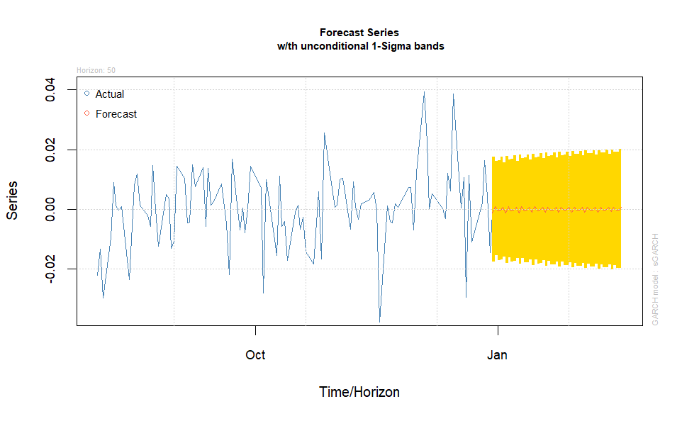

```r
0
```